# Homework4

##### d)

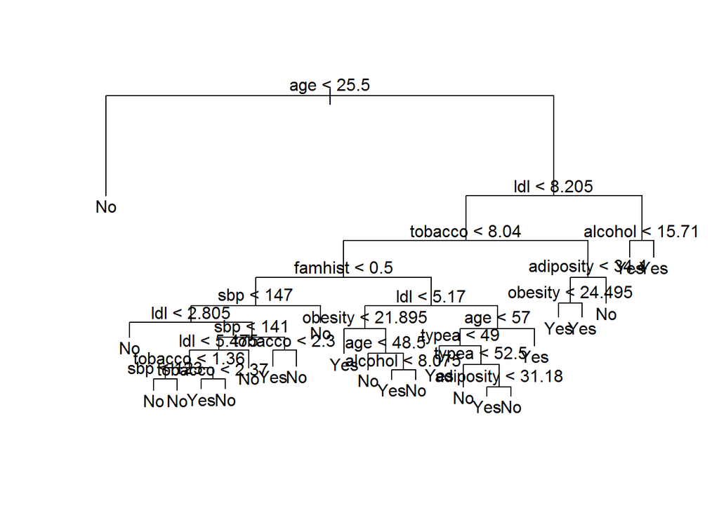

```r
plot(treeModel)
text(treeModel, pretty = 0)
```

###### e)

```r
treePred = predict(treeModel, SAheart_valid, type="class")
table(SAheart_valid$Present, treePred)
```

```
##      treePred
##        No Yes
##   No  121  39
##   Yes  41  30
```

##### f)

```r
treeCV = cv.tree(treeModel, FUN=prune.misclass)
names(treeCV)
```

```
## [1] "size"   "dev"    "k"      "method"
```

```r
treeCV
```

```
## $size
## [1] 24 21 15 11  8  6  4  1
##
## $dev
## [1] 81 78 82 83 82 78 84 90
##
## $k
## [1]     -Inf 0.000000 1.000000 1.250000 1.666667 4.000000 5.000000 8.333333
##
## $method
## [1] "misclass"
##
## attr(,"class")
## [1] "prune"         "tree.sequence"
```

The tree with 6 terminal nodes results in the lowest cross-validation error rate, 78

##### g)

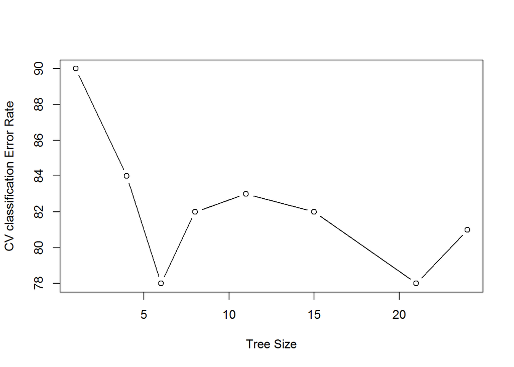

```r
plot(treeCV$size ,treeCV$dev ,type="b", xlab="Tree Size", ylab="CV classification Error Rate")
```

##### h)

When size = 6, result for cross-validation error rate is lowest.

##### i)

```r
treePrune =prune.misclass(treeModel ,best = 6)
```

##### j)

```r
summary(treePrune)
```

```
##
## Classification tree:
## snip.tree(tree = treeModel, nodes = c(7L, 24L, 51L, 13L, 50L))
## Variables actually used in tree construction:
## [1] "age"     "ldl"     "tobacco" "famhist"
## Number of terminal nodes:  6
## Residual mean deviance:  1.013 = 228 / 225
## Misclassification error rate: 0.2338 = 54 / 231
```

Misclassification error rate is 23.38%, which is higher than before.

##### k)

```r
treePrunePred = predict(treePrune, SAheart_valid, type="class")
table(SAheart_valid$Present, treePrunePred)
```

```
##      treePrunePred
##        No Yes
##   No  133  27
##   Yes  37  34
```

Test error rate is now (27+37)231 = 27.71%, which is lower than before.

##### (4b i & ii)

```r
library(randomForest)
library(caret)
```

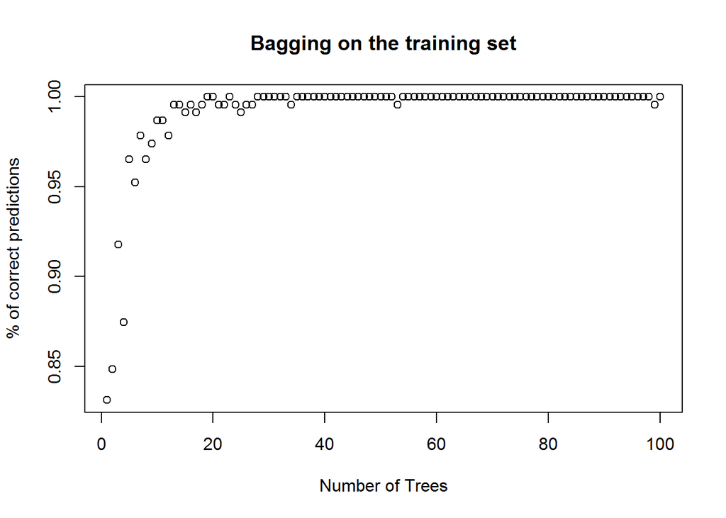

```r
train.errors = rep(0, 100)
test.errors = rep(0, 100)
for (i in 1:100) {
 tree.bag = randomForest(Present~., SAheart_train, mtry=9, ntree=i, importance=TRUE)
 yhat.bag = predict(tree.bag, SAheart_train)
 yhat.bag.test = predict(tree.bag, SAheart_valid)
 train.errors[i] = confusionMatrix(yhat.bag, SAheart_train$Present)$overall[1]
 test.errors[i] = confusionMatrix(yhat.bag.test, SAheart_valid$Present)$overall[1]
}
plot(train.errors, xlab="Number of Trees", ylab="% of correct predictions", main="Bagging on the training set")
```

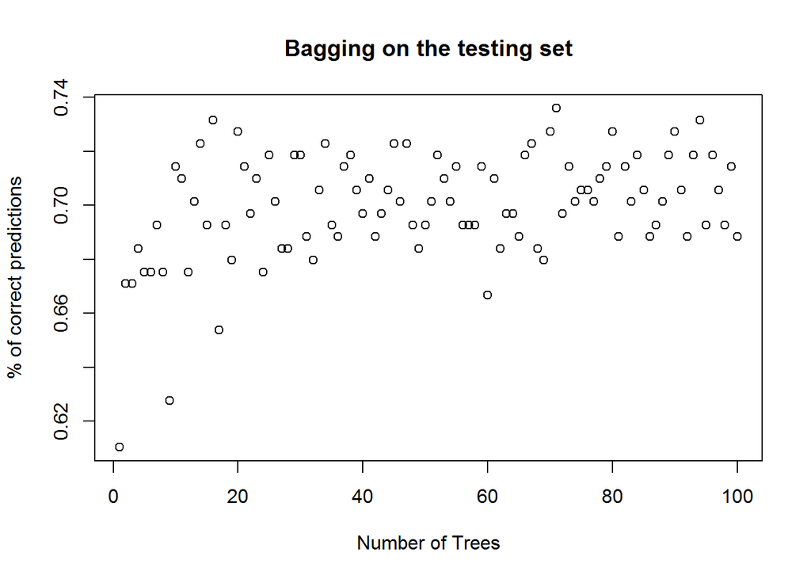

```r
plot(test.errors, xlab="Number of Trees", ylab="% of correct predictions", main="Bagging on the testing set")
```

##### (4b iii)

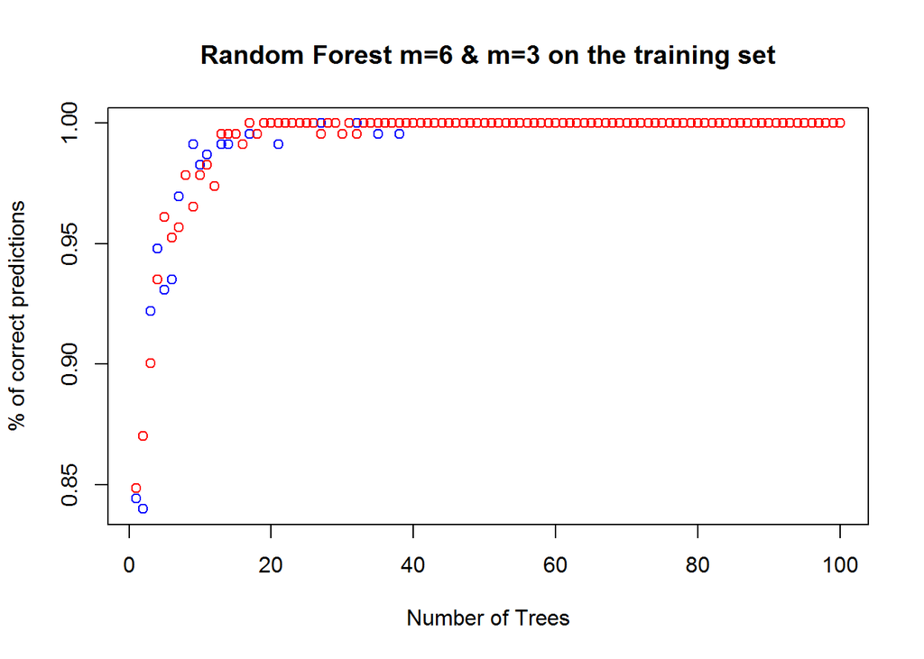

```r
train.errors1 = rep(0, 100)
train.errors2 = rep(0, 100)
test.errors1 = rep(0, 100)
test.errors2 = rep(0, 100)
for (i in 1:100) {
  rf1 = randomForest(Present~., SAheart_train, mtry=6, ntree=i, importance = TRUE)
  rf2 = randomForest(Present~., SAheart_train, mtry=3, ntree=i, importance = TRUE)
 yhat.rf1 = predict(rf1, SAheart_train)
 yhat.rf2 = predict(rf2, SAheart_train)
 yhat.rf1.test = predict(rf1, SAheart_valid)
 yhat.rf2.test = predict(rf2, SAheart_valid)
 train.errors1[i] = confusionMatrix(yhat.rf1, SAheart_train$Present)$overall[1]
 test.errors1[i] = confusionMatrix(yhat.rf1.test, SAheart_valid$Present)$overall[1]
 train.errors2[i] = confusionMatrix(yhat.rf2, SAheart_train$Present)$overall[1]
 test.errors2[i] = confusionMatrix(yhat.rf2.test, SAheart_valid$Present)$overall[1]
}
x=seq(1, 100)
plot(x, train.errors1, xlab="Number of Trees", ylab="% of correct predictions", type="p", main="Random Forest m=6 & m=3 on the training set", col="blue")
points(x, train.errors2, col="red")
```

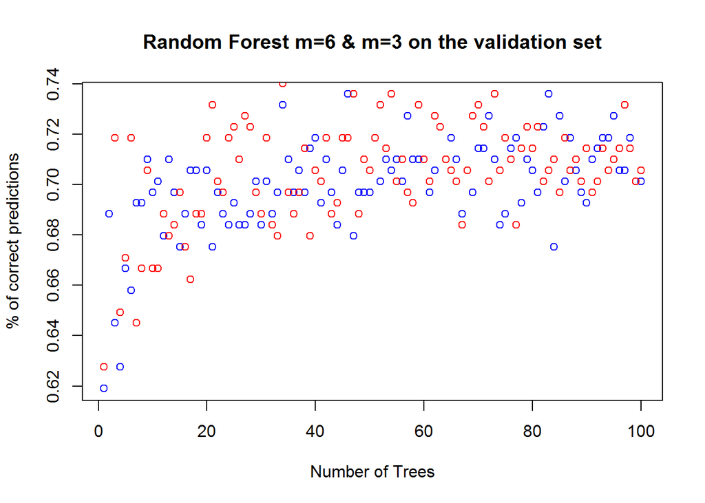

```r
plot(x, test.errors1, xlab="Number of Trees", ylab="% of correct predictions", type="p", main="Random Forest m=6 & m=3 on the validation set", col="blue")
points(x, test.errors2, col="red")
```

##### (4c iii)

This is similar as in Bagging. As we can see the training set accuracy is quickly increasing towards to 100%. However, it also cause overfit which doesn’t improve accuracy of valid set prediction much after B > 20.

##### (4d)

```r
# i & ii
library(gbm)
pows = seq(-10, -0.2, by=0.1)
lambdas = 10^pows
length.lambdas = length(lambdas)
train.errors3 = rep(0, length.lambdas)
test.errors3 = rep(0, length.lambdas)
SAheart_train <- SAheart[train,]
SAheart_train <- SAheart_train[,-11]
SAheart_validation <- SAheart[valid,]
SAheart_validation <- SAheart_validation[,-11]
for (i in 1:length.lambdas) {
   tree.boost = gbm(chd~., data = SAheart_train, distribution = "bernoulli", n.trees = 1000, shrinkage = i, verbose = F)
   yhat.boost = predict(tree.boost, SAheart_train, n.trees = 1000,  type="response")
   yhat.boost.test = predict(tree.boost, SAheart_validation, n.trees = 1000,  type="response")
   yhat.boost1 = ifelse(yhat.boost>=0.5, 1, 0)
   yhat.boost1.test = ifelse(yhat.boost.test>=0.5, 1, 0)
   train.errors3[i] = confusionMatrix(yhat.boost1, SAheart_train$chd)$overall[1]
   test.errors3[i] = confusionMatrix(yhat.boost1.test, SAheart_validation$chd)$overall[1]
}
```

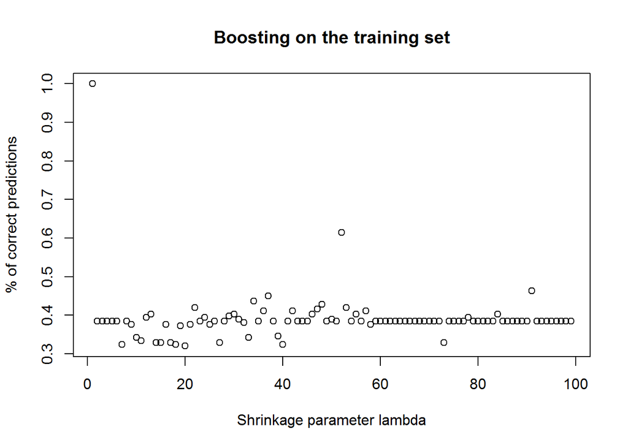

```r
plot(train.errors3, xlab="Shrinkage parameter lambda", ylab="% of correct predictions", main="Boosting on the training set")
```

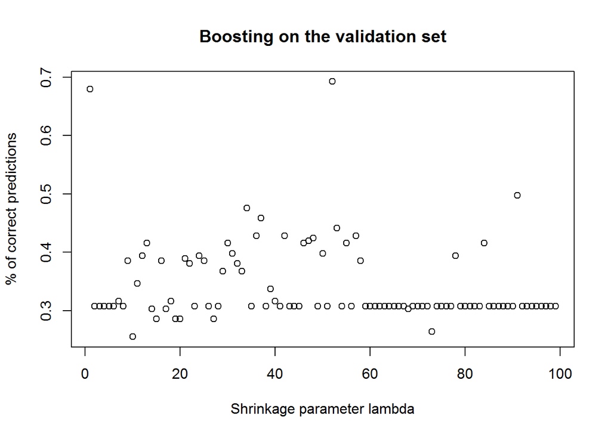

```r
plot(test.errors3,xlab="Shrinkage parameter lambda", ylab="% of correct predictions", main="Boosting on the validation set")
```

#### Problem 5

##### (a)

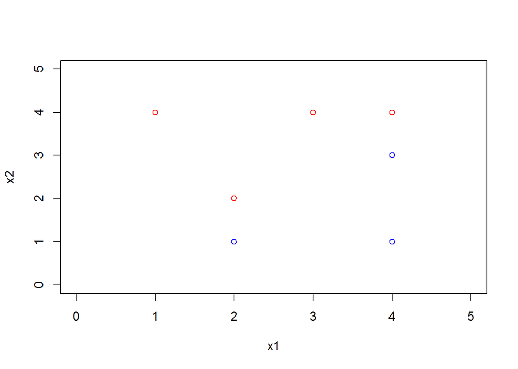

```r
x1 = c(3, 2, 4, 1, 2, 4, 4)
x2 = c(4, 2, 4, 4, 1, 3, 1)
colors = c("red", "red", "red", "red", "blue", "blue", "blue")
plot(x1, x2, col = colors, xlim = c(0, 5), ylim = c(0, 5))
```

##### (b)

(2,2), (4,4) (2,1), (4,3) => (2,1.5), (4,3.5) b = (3.5 - 1.5) / (4 - 2) = 1 a = X2 - X1 = 1.5 - 2 = -0.5

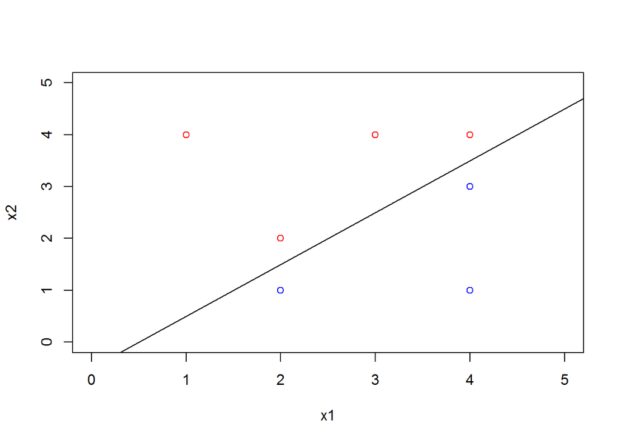

```r
plot(x1, x2, col = colors, xlim = c(0, 5), ylim = c(0, 5))
abline(-0.5, 1)
```

##### (c)

0.5 - X1 + X2 > 0

##### (d)

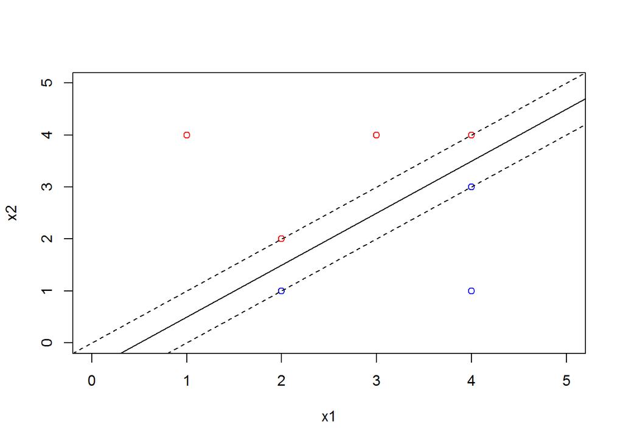

```r
plot(x1, x2, col = colors, xlim = c(0, 5), ylim = c(0, 5))
abline(-0.5, 1)
abline(-1, 1, lty = 2)
abline(0, 1, lty = 2)
```

##### (e)

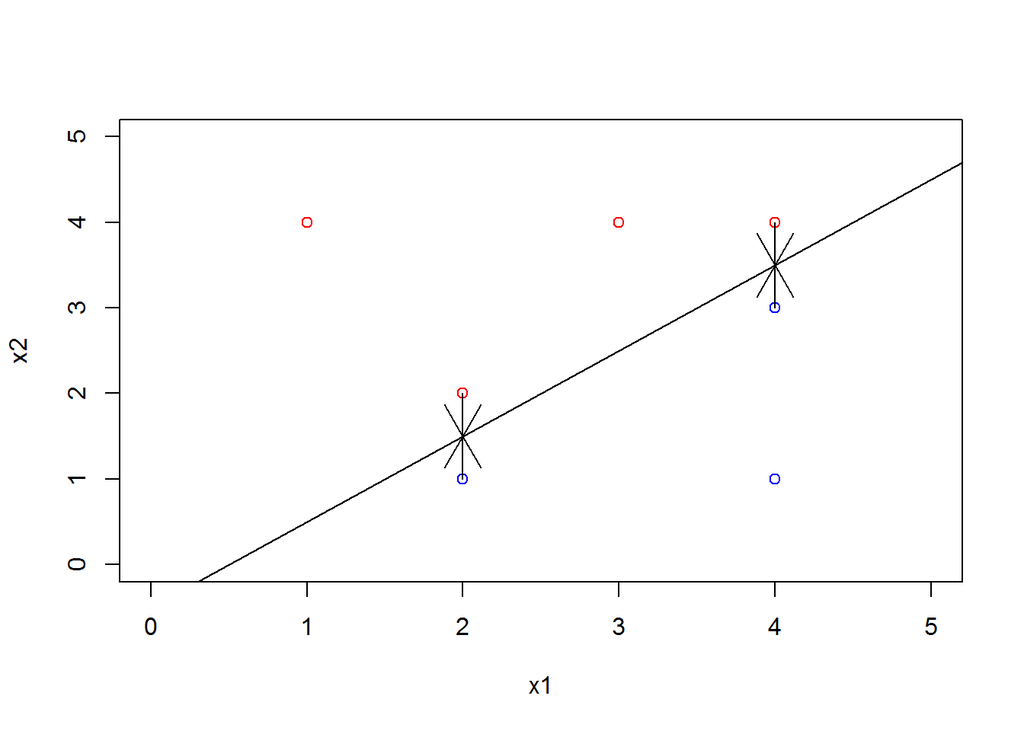

```r
plot(x1, x2, col = colors, xlim = c(0, 5), ylim = c(0, 5))
abline(-0.5, 1)
arrows(2, 1, 2, 1.5)
arrows(2, 2, 2, 1.5)
arrows(4, 4, 4, 3.5)
arrows(4, 3, 4, 3.5)
```

##### (f)

A slight movement of observation #7 (4,1) blue would not have an effect on the maximal margin hyperplane because it is out of margin and far from it.

##### (g)

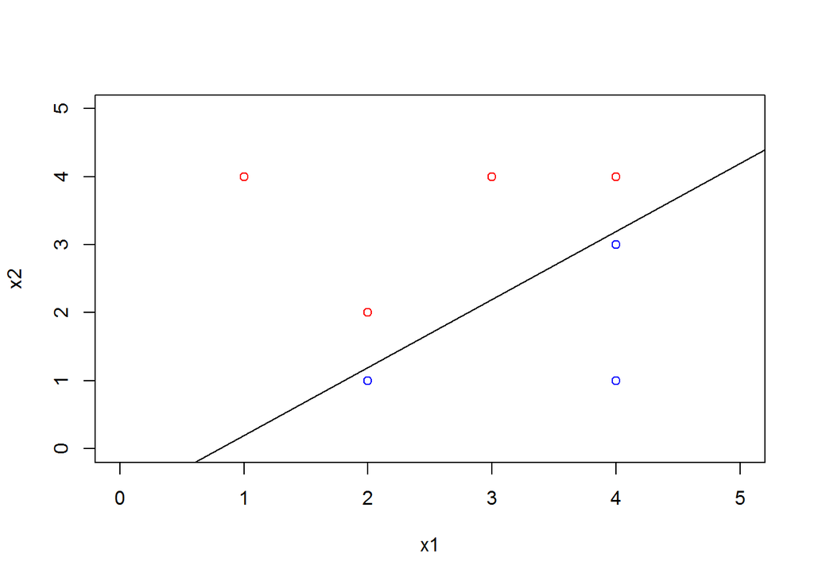

```r
plot(x1, x2, col = colors, xlim = c(0, 5), ylim = c(0, 5))
abline(-0.8, 1)
```

##### (h)

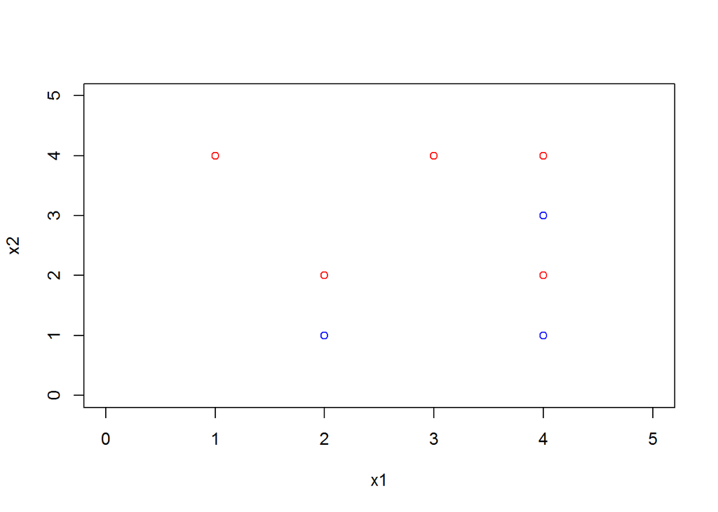

```r
plot(x1, x2, col = colors, xlim = c(0, 5), ylim = c(0, 5))
points(c(4), c(2), col = c("red"))
```